# 迴歸分析

## 什麼是迴歸分析？為什麼要做迴歸分析？

- 當隨機變數與某些已知的獨立變數相關時，我們該如何做分析？
  - 獨立變數是類別型變數：變異數分析
  - 獨立變數是數值型變數：迴歸分析

## 迴歸分析的原理

- \(E(Y_i) = \alpha + \beta x_i\)
- \(Var(Y_i) = \sigma^2\)

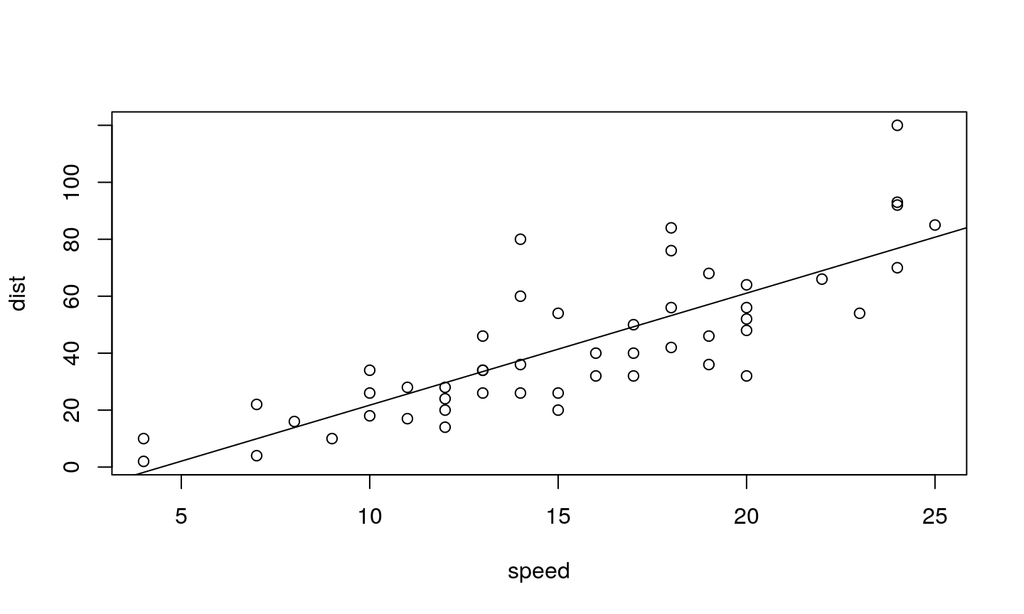

## 迴歸分析的原理

### 最小平方法（數學的觀點）

- 給定資料點\((y_1, x_1), (y_2, x_2), ..., (y_n, x_n)\)
- 模型的誤差為：\(r_i = y_i - (\alpha + \beta x_i)\)
- 我們要讓誤差的平方和最小，則：
  - \(\hat{\beta}_{LS} = \frac{S_{xy}}{S_xx}\), \(S_{xx} = \sum_{i=1}^n(x_i - \bar{x})^2, S_{xy} = \sum_{i=1}^n(x_i-\bar{x})(y_i - \bar{y})\)
  - \(\hat{\alpha}_{LS} = \bar{y} - \hat{\beta}_{LS} \bar{x}\)

## 迴歸分析的原理

### 最佳線性估計法（統計的觀點）

- 給定資料點\((y_1, x_1), (y_2, x_2), ..., (y_n, x_n)\)
- 假設\(Y_i = \alpha + \beta x_i + \varepsilon_i\)
  - \(E(\varepsilon_i) = 0, Var(\varepsilon_i) = \sigma^2\)
- 我們只考慮可以寫成\(\sum_{i=1}^n d_i y_i\)的估計
  - 若是\(\beta\)的不偏估計：\(\beta = E(\sum_{i=1}^n d_i y_i) = \alpha (\sum_{i=1}^n d_i) + \beta (\sum_{i=1}^n d_i x_i)\)
  - \(Var(\sum_{i=1}^n d_i y_i) = \sigma^2 \sum_{i=1}^n d_i^2\)
- 從統計的觀點，我們希望不偏的同時，\(Var(\sum_{i=1}^n d_i y_i)\)越小越好

## 迴歸分析的原理

### 最佳線性估計法（統計的觀點）

3\[\left\{\begin{array}{l} \sum_{i=1}^n d_i = 0 \\ \sum_{i=1}^n d_i x_i = 1 \\ \sum_{i=1}^n d_i^2 \text{ 最小} \end{array}\right.\]

- 可以證明，\(d_i = \frac{x_i - \bar{x}}{S_{xx}}\)符合條件，而答案則會與最小平方法相同

## 迴歸分析的原理

- 再假設\(Y_i | x_i \sim \mathcal{N}(\alpha + \beta x_i, \sigma^2)\)
- 有分佈，我們就可以計算最大概似估計：
  - \(\hat{\alpha}_{MLE}\) 與 \(\hat{\beta}_{MLE}\) 仍然與最小平方法一樣
- \(\sigma^2\)的最大概似估計，與常態分佈的狀況一樣，是有偏差的。所以人們更常用不偏的：

\[S^2 = \frac{1}{n-2} \sum_{i=1}^n(y_i - \hat{\alpha} - \hat{\beta} x_i)^2\]

## 迴歸分析的方法

### t 檢定

- 當以下狀況發生時，\(H_0: \beta = 0\)會被拒絕：

\[\left|\frac{\hat{\beta}}{S / \sqrt{S_{xx}}}\right| > t_{n-2,\frac{\alpha}{2}}\]

- 或是\(\beta\)的信賴區間為：

\[\left[\hat{\beta} - t_{n-2, \alpha/2} \frac{S}{\sqrt{S_{xx}}}, \hat{\beta} + t_{n-2, \alpha/2} \frac{S}{\sqrt{S_{xx}}}\right]\]

## 迴歸分析的方法

### F 檢定

- 或是當以下狀況發生時，\(H_0: \beta = 0\)會被拒絕：

\[\frac{\hat{\beta}^2}{S^2 / S_{xx}} > F_{1,n-2,\alpha}\]

## 迴歸分析的方法

### 與變異數分析的比較

\[\sum_{i=1}^n (y_i - \bar{y})^2 = \sum_{i=1} (\hat{y_i} - \bar{y})^2 + \sum_{i=1}^n (y_i - \hat{y})^2\]

- 如果迴歸模型有效，我們希望\(\sum_{i=1} (\hat{y_i} - \bar{y})^2\) 越大越好，這代表用迴歸模型解釋的變化
- \(\sum_{i=1}^n (y_i - \hat{y})^2\)代表模型無法解釋的變化，也就是隨機的變化

## 迴歸分析的方法

### 與變異數分析的比較

- 可以證明F檢定的算式等價：

\[\frac{\sum_{i=1} (\hat{y_i} - \bar{y})^2}{\sum_{i=1}^n (y_i - \hat{y})^2 / (n - 2)}\]

- 也是在比較兩者的變化

## 總結

- 當獨立變數是數值型態時，我們可以用迴歸分析。這裡介紹了迴歸分析的方法
- 無論是變異數分析還是迴歸分析，F檢定，最終都等價於比較「模型解釋的變化」與「隨機的變化」

## 預測

- 給定\(x = x_0\)時，根據\(\hat{\alpha}, \hat{\beta}\)我們可以預測\(\hat{y}_0 = \alpha + \beta x_0\)
- 如果\(Y_i | x_i \sim \mathcal{N}(\alpha + \beta x_i, \sigma^2)\)則：

\[\hat{y}_0 \sim \mathcal{N} \left(\alpha + \beta x_0 , \sigma^2\left(\frac{1}{n} + \frac{(x_0 - \bar{x})^2}{S_{xx}} \right)\right)\]

\[\frac{(\hat{\alpha} + \hat{\beta} x_0) - (\alpha + \beta x_0)}{S \sqrt{\frac{1}{n} + \frac{(x_0 - \bar{x})^2}{S_{xx}}}} \sim t_{n-2}\]

- \(\hat{y} | x_0\) 的信賴區間為：

\[\left[\hat{\alpha} + \hat{\beta} x_0 - t_{n-2, \alpha/2} S \sqrt{\frac{1}{n} + \frac{(x_0 - \bar{x})^2}{S_{xx}}} , \hat{\alpha} + \hat{\beta} x_0 + t_{n-2, \alpha/2} S \sqrt{\frac{1}{n} + \frac{(x_0 - \bar{x})^2}{S_{xx}}} \right]\]

## 預測

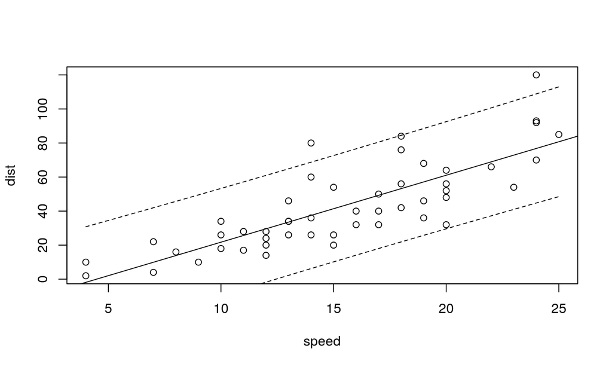